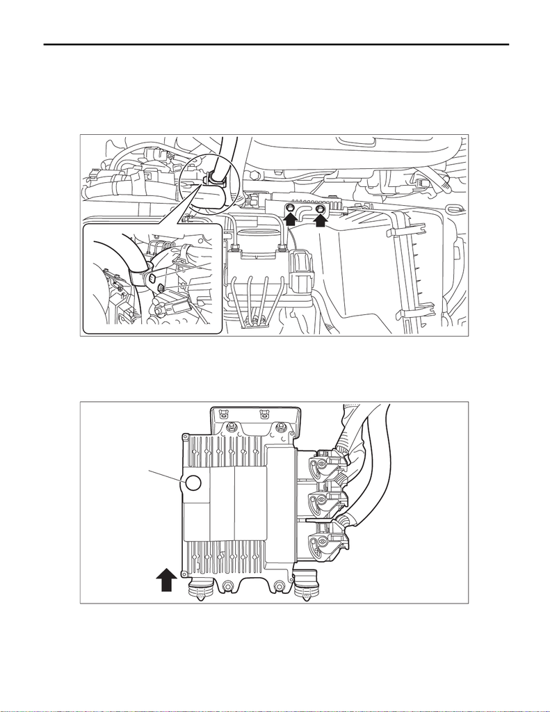

IN(w/o STI)-9

Air Cleaner Case

INTAKE (INDUCTION)

3. Air Cleaner Case

A: REMOVAL

1) Disconnect the ground terminal from battery sensor. <Ref. to NT-5, BATTERY, NOTE, Note.>

2) Remove the air intake duct. <Ref. to IN(w/o STI)-22, REMOVAL, Air Intake Duct.>

3) Remove the clips (A) and (B) which secure the engine harness and bulkhead harness to the bracket, and

remove the bolt which secures the engine control module (ECM) to the bracket.

4) Pull out the engine control module (ECM) from the bracket, and move it to a location that does not interfere

operation.

NOTE:

When performing the pulling out operation, pay attention not to apply excessive load to the breather filter por-

tion (a) in order to avoid the damage.

IN-03579

(B)

(A)

IN-03580

(a)

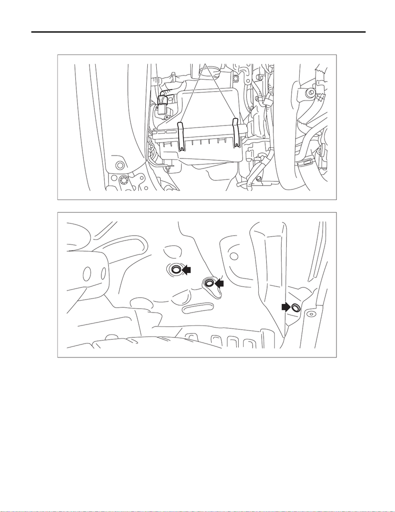

IN(w/o STI)-10

Air Cleaner Case

INTAKE (INDUCTION)

5) Disconnect the connector (A) from the mass air flow and intake air temperature sensor, and remove the

clip (B) from the air cleaner case (rear).

6) Remove the clips (3 places) which secure the front mud guard RH to the vehicle.

(A)

(B)

IN-03551

IN-03549

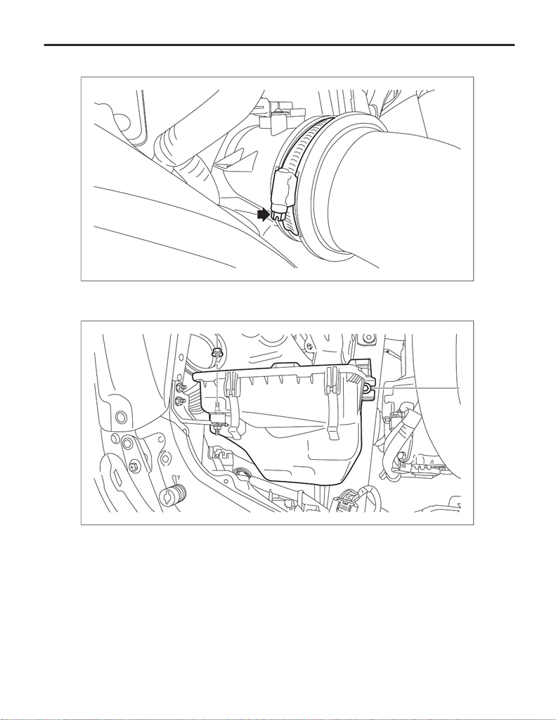

IN(w/o STI)-11

Air Cleaner Case

INTAKE (INDUCTION)

7) Turn over the front mud guard RH, and loosen the clamp which secures the air intake boot to the air clean-

er case (rear).

8) Remove the air cleaner case (rear) and air cleaner element.

9) Remove bolts (A) and nuts (B) which secure the air cleaner case (front) to the body and air cleaner case

bracket, and remove the air cleaner case (front).

IN-03550

(B)

(A)

IN-03552

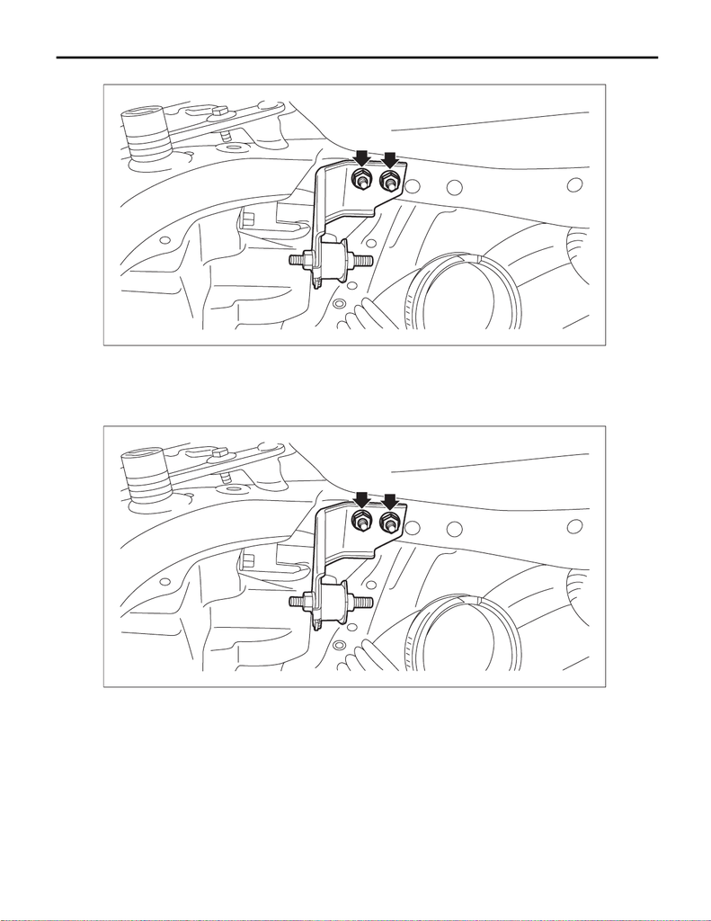

IN(w/o STI)-12

Air Cleaner Case

INTAKE (INDUCTION)

10) Remove the air cleaner case bracket from the vehicle.

B: INSTALLATION

1) Install the air cleaner case bracket to the vehicle.

Tightening torque:

7.5 N·m (0.8 kgf-m, 5.5 ft-lb)

IN-03553

IN-03553

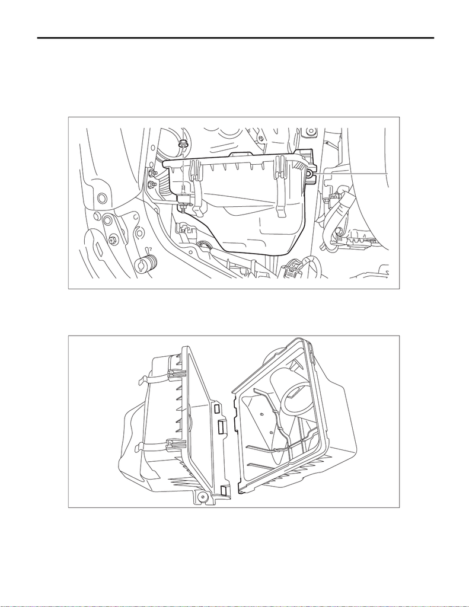

IN(w/o STI)-13

Air Cleaner Case

INTAKE (INDUCTION)

2) Install the bolt (A) and nut (B) which secure the air cleaner case (front) to the vehicle and to the air cleaner

case bracket.

Tightening torque:

Bolt (A)

6 N·m (0.6 kgf-m, 4.4 ft-lb)

Nut (B)

7.5 N·m (0.8 kgf-m, 5.5 ft-lb)

3) Set the air cleaner element and air cleaner case (rear) to the air cleaner case (front).

NOTE:

When setting the air cleaner case (rear), align the protrusion of the air cleaner case (rear) to the air cleaner

case (front) to insert.

(B)

(A)

IN-03552

IN-03357

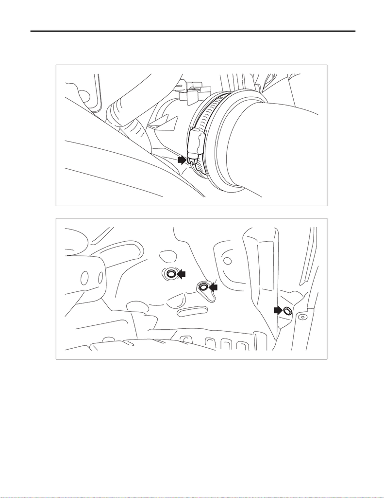

IN(w/o STI)-14

Air Cleaner Case

INTAKE (INDUCTION)

4) Tighten the clamp which secures the air intake boot to the air cleaner case (rear).

Tightening torque:

2.5 N·m (0.3 kgf-m, 1.8 ft-lb)

5) Set the front mud guard RH to the vehicle, and install the clips which secure the front mud guard RH.

IN-03550

IN-03549

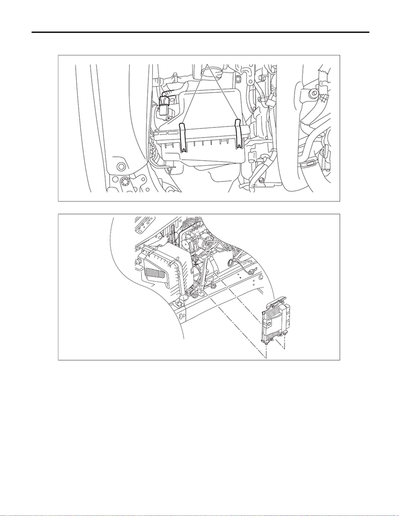

IN(w/o STI)-15

Air Cleaner Case

INTAKE (INDUCTION)

6) Install the clip (B) to the air cleaner case (rear), and connect the connector (A) to the mass air flow and in-

take air temperature sensor.

7) Insert the engine control module (ECM) to the bracket.

(A)

(B)

IN-03551

FU-08492

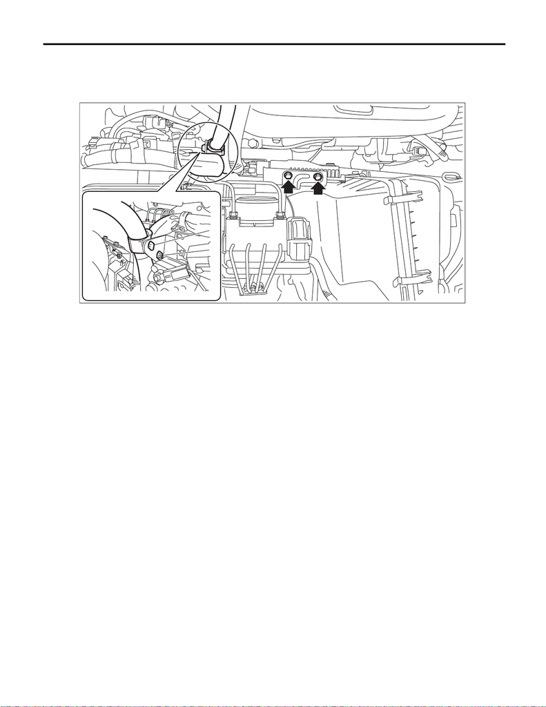

IN(w/o STI)-16

Air Cleaner Case

INTAKE (INDUCTION)

8) Install the bolt which secures the engine control module (ECM) to the bracket, and then secure the engine

harness and bulkhead harness to the bracket with clips (A) and (B).

Tightening torque:

7.5 N·m (0.8 kgf-m, 5.5 ft-lb)

9) Install the air intake duct. <Ref. to IN(w/o STI)-22, INSTALLATION, Air Intake Duct.>

10) Connect the ground terminal to battery sensor. <Ref. to NT-5, BATTERY, NOTE, Note.>

C: INSPECTION

Check that the air cleaner case has no deformation, cracks or other damages.

IN-03579

(B)

(A)